# Feature-wide Effect Heterogeneity of Retirement on Subsequent Health through Causal Forests

Shingo Nitta

Japan Society for the Promotion of Science, Gakushuin University

2025-03-14

# Introduction

## Does Retirement Improve Health?

Extending working lives is a growing concern for policymakers to sustain the social welfare as the life expectancies rapidly increase

- If retirement *improves* subsequent health, extending working lives and health promotion are mutually exclusive, and policymakers need to choose one
- If retirement *worsens* subsequent health, extending working lives policy results in the better health, resulting in the sustainable care system

**Reseach question**

Does retirement improve or worsen subsequent health?

## Theory and Evidence are Mixed

**Health capital model**<sup>1</sup>

- Retirement *improves* health
  - it decreases opportunity costs of health investment
- Retirement *worsens* health
  - retirees no longer have benefits of investigating health, which is a linchpin of miximizing lifetime earnings<sup>2</sup>

Evidence is also mixed

- Positive effect<sup>3–8</sup>, negative effect<sup>9–12</sup>, null effect<sup>13–15</sup>, both positive and negative effect<sup>16–19</sup>

## Effect Heterogeneity

Why does the effect vary? **Effect heterogeneity**

- gender<sup>7,8,10,12,16,18,20</sup>
- job before retirement<sup>3–5,13,21</sup>

Studies partly progress, but …

1. some heterogeneity is still inconsistent<sup>12,18</sup>
2. *additional* social determinants are not considered
3. *interconnectedness* of social determinants are not considered

## *Feature-wide* Effect Heterogeneity

Comprehensive heterogeneity by multiple features and their interaction

- a kind of abductive inference<sup>22,23</sup>
  - a loose set of beliefs that can be modified by subsequent evidence<sup>24</sup>
- achieved by causal forests<sup>25–28</sup>
  - a machine learning approach
  - ‘honesty’ (i.e., cross-fitting)

I newly answer the research question of ‘does retirement improve or worsen subsequent health?’ by applying feature-wide effect heterogeneity approach

# Data and Methods

## Data and Sample

**Gateway to Global Aging Data** (the Gateway)<sup>29</sup>

- consists of HRS in USA, MHAS in Mexico, SHARE in Europe, ELSA in Britain, CHARLS in China, and KLoSA in Korea
- 272352 individuals and 983904 person-biennial observations

Sample

- 50-75 years old
- individuals with three waves
- pooled cross-sectional data
- listwise deletion (n=101314)

## Features

**Outcome** ($t+1$)

- subjective health (higher score indicates worse health)

**Treatment** ($t$)

- working status (retired = work at $t-1$ and not work at $t$, non-retired = work at $t-1$ and work at $t$)

**Modifier** ($t-1$)

Gender, age, birth cohort, survey year, education, marital status, household income, household wealth, working hours, employment status (self-employed or not), household size, number of living parents, father’s age and mother’s age, number of living children, transfer to (grand)children, number of living siblings

## Causal Forests: Overview

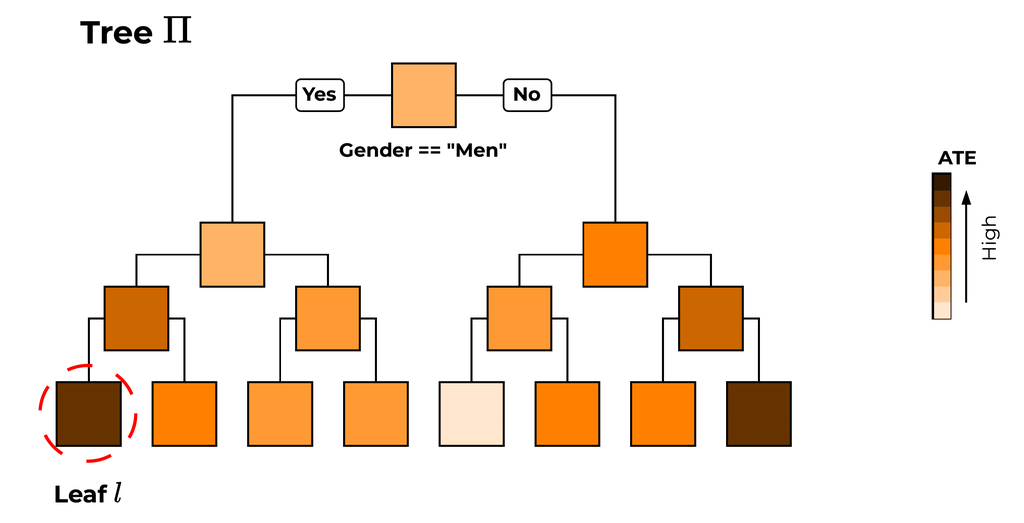

An Example of causal forests

## Causal Forests: Estimand

$$\tau = \frac{1}{\Sigma_{i=1}^n w_i} \Sigma_{i=1}^n w_i \left[ Y_i(1) - Y_i(0) \mid \vec{X_i} \in l(\vec{x} ; \Pi) \right]
\qquad(1)$$

**Notation**

- $n$: sample size
- $X$: feature space
- $x$: given features
- $\Pi$：partition of feature space
- $Y(\cdot)_i$：oucome of a given individual $i$ under treatment $1$ (treated) or $0$ (control)
- $w_i$: probability of treatment

$w_i$ is obtained through logistic regression model with subjective health at $t-1$ and other modifiers

## Causal Forests: Metrics

$$-\widehat{EMSE}_{\tau(\vec{x} )} = \frac{1}{N_{tr}} \sum_{i \in \mathcal{S}^{tr}} \widehat{\tau}^2(\vec{X_i}; \mathcal{S}^{tr}, \Pi) - \left( \frac{1}{N_{tr}} + \frac{1}{N_{es}} \right) \sum_{l \in \Pi} \left( \frac{S^2_{\mathcal{S}^{tr}(1)}(l)}{p(l)} + \frac{S^2_{\mathcal{S}^{tr}(0)}(l)}{1 - p(l)} \right)$$

**Notation**

- $\mathcal{S}^{tr}$: training sample
- $N^{tr}$: size of training sample
- $N^{es}$: size of estimation sample
- $\widehat{\tau}^2$: variance of CATE
- $S^2_{*}(l)$: variance of outcome within a leaf $l$
- $p(l)$: the proportion of treated units in leaf $l$

The first term considers about variance of CATE *across* leaves and the second terms considers about variance of outcome *within* leaves

# Results

## A Representative Causal Tree

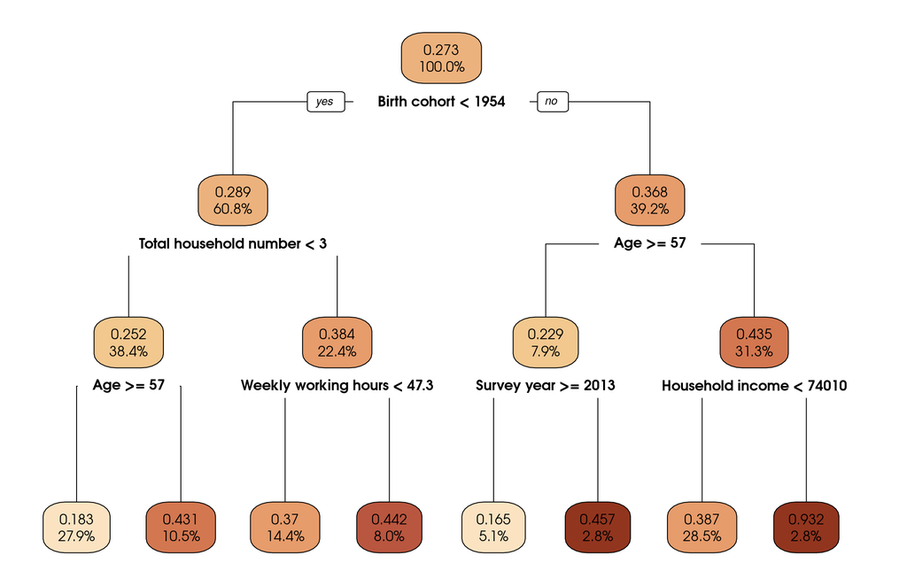

Causal Tree of Retirement and Subsequent Health

## Feature Importance

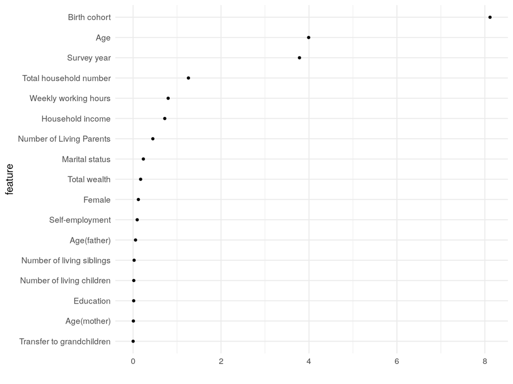

Feature Importance

# Discussion

## Summary and Interpretation of the Results

Overall, the effect is negative

What makes effect heterogeneous?

**temporal dynamics**

- pension eligibility, extending working lives policy or Great Recession

**financial insecurity**

- decrease of living standards

**work characteristics**

- loss of ‘verified’ role-identity?<sup>30</sup>

Sociodemographic features (sex and education) are less important

## Contribution and Future Analyses

Deciphering what heterogenizes the effect of retirement on subsequent health through an abductive approach

- with the model metric for partitioning and unbiased estimation

**Disentangling temporal dimensions**

- Pension eligibility, retirement timing, and global shock (e.g., Great Recession, COVID-19)

**Detailed work characteristics**

- Occupation, industry and workplace

## Acknowledgement

This work was supported by Grant-in-Aid for JSPS Fellows JP24KJ1919.

## References

78th Japanese Association of Mathematical Sociology

1.

Grossman, M. [On the Concept of Health Capital and the Demand for Health](https://doi.org/10.1086/259880). *Journal of Political Economy* **80**, 223–255 (1972).

2.

Dave, D., Rashad, I. & Spasojevic, J. [The Effects of Retirement on Physical and Mental Health Outcomes](https://doi.org/10.1002/j.2325-8012.2008.tb00916.x). *Southern Economic Journal* **75**, 497–523 (2008).

3.

Bogaard, L. van den, Henkens, K. & Kalmijn, M. [Retirement as a Relief? The Role of Physical Job Demands and Psychological Job Stress for Effects of Retirement on Self-Rated Health](https://doi.org/10.1093/esr/jcv135). *European Sociological Review* **32**, 295–306 (2016).

4.

Bloemen, H., Hochguertel, S. & Zweerink, J. [The causal effect of retirement on mortality: Evidence from targeted incentives to retire early](https://doi.org/10.1002/hec.3493). *Health Economics* **26**, e204–e218 (2017).

5.

Qvist, J. Y. [Early Retirement and Social Class: A Health-Giving Choice for All?](https://doi.org/10.1093/esr/jcac029) *European Sociological Review* **39**, 132–144 (2022).

6.

Okamoto, S., Kobayashi, E. & Komamura, K. [The Retirement–Health Puzzle: A Sigh of Relief at Retirement?](https://doi.org/10.1093/geronb/gbac127) *The Journals of Gerontology: Series B* **78**, 167–178 (2022).

7.

Zhao, M., Konishi, Y. & Noguchi, H. [Retiring for better health? Evidence from health investment behaviors in Japan](https://doi.org/10.1016/j.japwor.2017.06.003). *Japan and the World Economy* **42**, 56–63 (2017).

8.

Oshio, T. & Kan, M. [The dynamic impact of retirement on health: Evidence from a nationwide ten-year panel survey in Japan](https://doi.org/10.1016/j.ypmed.2017.04.007). *Preventive Medicine* **100**, 287–293 (2017).

9.

Okamoto, S., Okamura, T. & Komamura, K. [Employment and health after retirement in Japanese men](https://doi.org/10.2471/blt.18.215764). *Bulletin of the World Health Organization* **96**, 826–833 (2018).

10.

Barban, N., Luna, X. de, Lundholm, E., Svensson, I. & Billari, F. C. [Causal Effects of the Timing of Life-course Events: Age at Retirement and Subsequent Health](https://doi.org/10.1177/0049124117729697). *Sociological Methods & Research* **49**, 216–249 (2020).

11.

Pilehvari, A., You, W. & Lin, X. [Retirement’s impact on health: what role does social network play?](https://doi.org/10.1007/s10433-023-00759-w) *European Journal of Ageing* **20**, 14 (2023).

12.

Furuya, S. & Fletcher, J. M. Retirement Makes You Old? Causal Effect of Retirement on Biological Age. *Demography* (2024) doi:10.1215/00703370-11380637.

13.

Grøtting, M. W. & Lillebø, O. S. [Health effects of retirement: evidence from survey and register data](https://doi.org/10.1007/s00148-019-00742-9). *Journal of Population Economics* **33**, 671–704 (2020).

14.

Hult, C., Stattin, M., Janlert, U. & Järvholm, B. [Timing of retirement and mortality - A cohort study of Swedish construction workers](https://doi.org/10.1016/j.socscimed.2009.10.043). *Social Science & Medicine* **70**, 1480–1486 (2010).

15.

Gorry, D. & Slavov, S. N. [The effect of retirement on health biomarkers](https://doi.org/10.1016/j.ehb.2020.100949). *Economics & Human Biology* **40**, 100949 (2021).

16.

McDonough, P., Worts, D., Corna, L. M., McMunn, A. & Sacker, A. [Later-life employment trajectories and health](https://doi.org/10.1016/j.alcr.2017.09.002). *Advances in Life Course Research* **34**, 22–33 (2017).

17.

Calvo, E., Sarkisian, N. & Tamborini, C. R. [Causal Effects of Retirement Timing on Subjective Physical and Emotional Health](https://doi.org/10.1093/geronb/gbs097). *The Journals of Gerontology: Series B* **68**, 73–84 (2013).

18.

Xu, Y. [The effect of retirement on health and mortality in the United States](https://doi.org/10.1007/s12546-023-09307-w). *Journal of Population Research* **40**, 12 (2023).

19.

Mizuochi, M. Retirement Pathways’ Effect on Physical and Mental Health: Evidence from Japan. *Journal of Aging and Health* 8982643231200931 (2023) doi:10.1177/08982643231200931.

20.

Quaade, T., Engholm, G., Johansen, A. M. T. & Møller, H. [Mortality in relation to early retirement in Denmark: a population-based study](https://doi.org/10.1080/14034940210134022). *Scandinavian Journal of Public Health* **30**, 216–222 (2002).

21.

Scotti, B. [Late-Career Employment Trajectories and Postretirement Mortality: Evidence From Italy](https://doi.org/10.1215/00703370-10291269). *Demography* **59**, 2187–2213 (2022).

22.

Merton, R. K. [Three Fragments From a Sociologist’s Notebooks: Establishing the Phenomenon, Specified Ignorance, and Strategic Research Materials](https://doi.org/10.1146/annurev.so.13.080187.000245). *Annual Review of Sociology* **13**, 1–29 (1987).

23.

Swedberg, R. [Theorizing in Sociological Research: A New Perspective, a New Departure?](https://doi.org/10.1146/annurev-soc-060116-053604) *Annual Review of Sociology* **43**, 1–18 (2016).

24.

Engzell, P. & Mood, C. [Understanding Patterns and Trends in Income Mobility through Multiverse Analysis](https://doi.org/10.1177/00031224231180607). *American Sociological Review* **88**, 600–626 (2023).

25.

Athey, S. & Imbens, G. [Recursive partitioning for heterogeneous causal effects](https://doi.org/10.1073/pnas.1510489113). *Proceedings of the National Academy of Sciences* **113**, 7353–7360 (2016).

26.

Athey, S., Tibshirani, J. & Wager, S. [Generalized random forests](https://doi.org/10.1214/18-aos1709). *The Annals of Statistics* **47**, 1148–1178 (2019).

27.

Brand, J. E., Xu, J., Koch, B. & Geraldo, P. [Uncovering Sociological Effect Heterogeneity Using Tree-Based Machine Learning](https://doi.org/10.1177/0081175021993503). *Sociological Methodology* **51**, 189–223 (2021).

28.

Jawadekar, N. *et al.* [Practical Guide to Honest Causal Forests for Identifying Heterogeneous Treatment Effects](https://doi.org/10.1093/aje/kwad043). *American Journal of Epidemiology* **192**, 1155–1165 (2023).

29.

Lee, J., Phillips, D., Wilkens, J. & Team, G. to G. A. D. [Gateway to Global Aging Data: Resources for Cross-National Comparisons of Family, Social Environment, and Healthy Aging](https://doi.org/10.1093/geronb/gbab050). *The Journals of Gerontology: Series B* **76**, S5–S16 (2021).

30.

Mize, T. D. & Kincaid, R. Role-Accumulation and Mental Health across the Life Course. *American Sociological Review* (2025) doi:10.1177/00031224241313394.